# quantileplot

This R package has a companion working paper.

> Lundberg, Ian, Robin C. Lee, and Brandon M. Stewart. 2021. [“The quantile plot: A visualization for bivariate population relationships.”](https://ilundberg.github.io/quantileplot/doc/explainer.html) Working paper.

The `quantileplot` package visualizes bivariate associations. When summarizing bivariate data, a best-fit regression line often obscures important trends—it is too simple. A scatter plot shows all the data but overwhelms the viewer—it is too complicated. A `quantileplot` is a middle ground with three components.

1. The marginal density of the predictor variable.
2. The conditional density of the outcome at selected values of the predictor.
3. Smooth curves for conditional quantiles of the outcome as functions of the predictor.

A `quantileplot` may be useful in many settings. One example is when

- the predictor is skewed, so that (1) conveys useful information,
- the outcome is skewed, so that (2) conveys useful information, and
- the outcome is heteroskedastic, so that (3) conveys a set oof distinct trends.

This vignette illustrates the package functionality with a simulated example.

# Installation

The `quantileplot` package is available via GitHub.

- First, install the `devtools` package
- Then, type `devtools::install_github("ilundberg/quantileplot")`

# Basic functionality

Suppose we have a continuous predictor $X$ and a continuous outcome $Y$.

```r
library(quantileplot)
x <- rbeta(1000,1,2)
y <- log(1 + 9 * x) * rbeta(1000, 1, 2)
sim_data <- data.frame(x = x, y = y)
```

A call to the `quantileplot` function, produces the most basic quantile plot.

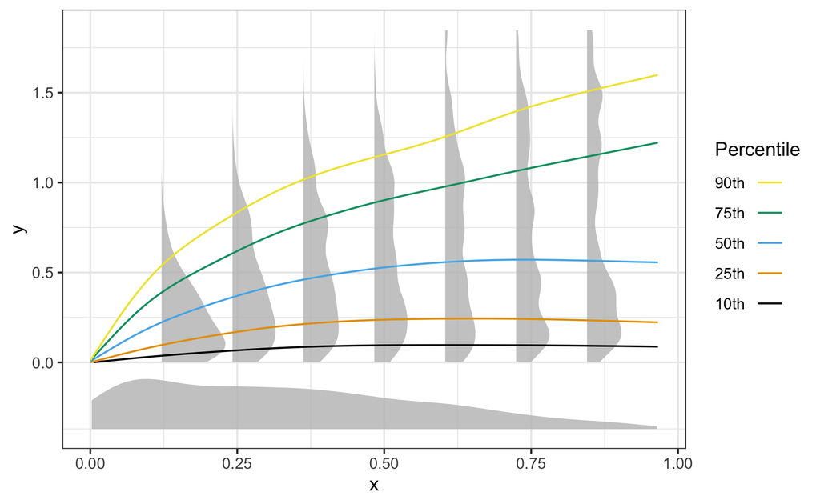

```r
quantileplot(y ~ s(x), data = sim_data)
```

A call to `quantileplot` may take some time to compute. In the simulated setting above, the time was 4 seconds for 1,000 observations and 24 seconds for 10,000 observations.

# Visualizing uncertainty

This most basic version of the visualization does not present any estimates of uncertainty. There are two options for visualizing uncertainty.

## Uncertainty method 1: Pointwise confidence bands

The argument `show_ci = T` will layer 95% pointwise credible interval bands on top of the estimated quantile curves. A credible interval is the Bayesian analog to a confidence interval, here supported by the default variance estimation methods in the `qgam` package.

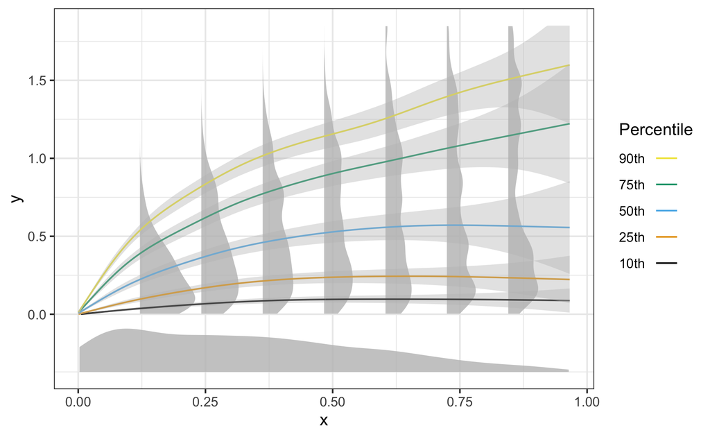

```r
quantileplot(y ~ s(x), data = sim_data, show_ci = T)
```

Importantly, these are **pointwise** credible intervals. At each predictor value $X = x$, they are designed to contain the middle 95% of the posterior distribution of the quantile of $Y$ given $X = x$. This is distinct from uncertainty statements about the entire curve. For example, it would be incorrect to conclude that over 95% of repeated draws the entire curve would fall within the plotted band.

The `ci` argument allows the user to specify a credible value other than 0.95 (e.g. for 90% confidence bands.)

## Uncertainty method 2: Posterior samples of curves

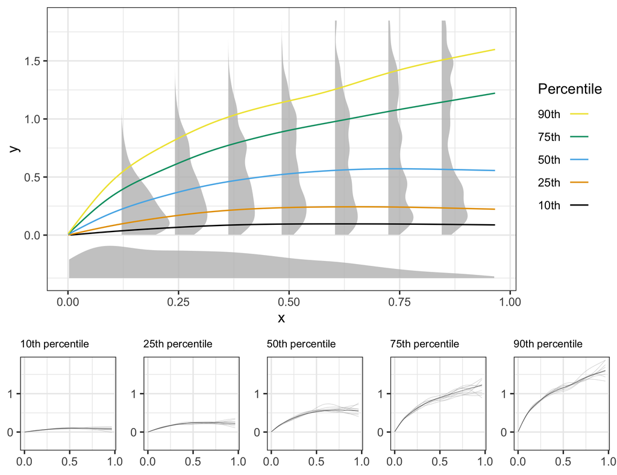

```r
quantileplot(y ~ s(x), data = sim_data, uncertainty_draws = 10)
```

Importantly, these curves are not like a confidence interval. They do not show the user a range such that the truth would fall in that range with some probability. Instead, they are useful to convey to the viewer the more basic idea that the estimated curve is only our best guess for a curve that is statistically uncertain.

# Visualizing the raw data

After creating a `quantileplot` object, you can convert that object into an analogous scatter plot to visualize the raw data. If desired in a large sample, you can use the `fraction` argument to plot some random fraction of the raw data.

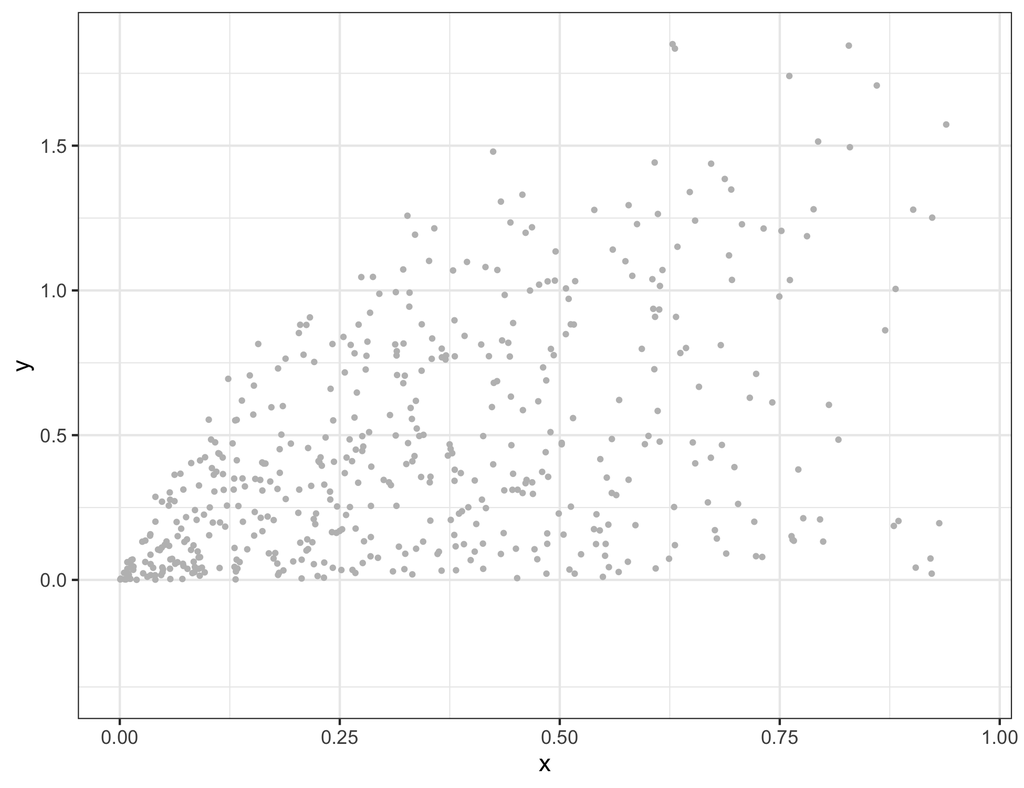

```r
qp <- quantileplot(y ~ s(x), data = sim_data)
scatter.quantileplot(qp, fraction = .5)
```

# Customizing the visualization

There are two ways to customize the plot: with arguments and by manually modifying the resulting `ggplot2` object.

## Customization 1: Arguments to `quantileplot`

You can customize many features of the plot with arguments to the `quantileplot` function.

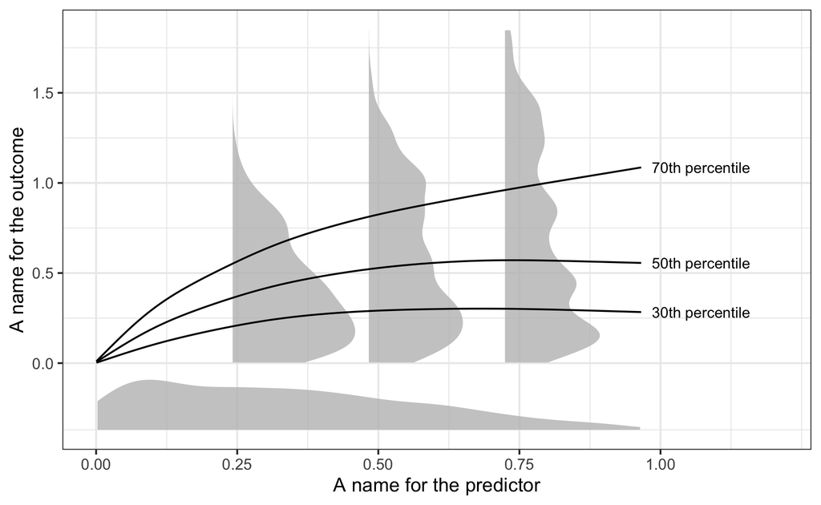

```r
quantileplot(
  y ~ s(x),
  data = sim_data,
  # Provide axis titles
  xlab = "A name for the predictor",
  ylab = "A name for the outcome",
  # Customize the number of vertical slices
  slice_n = 3,
  # Customize which quantiles are depicted
  quantiles = c(.3,.5,.7),
  # Denote quantiles by colors with labels instead of colors
  quantile_notation = "label"
)
```

If predictors are extremely skewed, you may only want to visualize part of the space. For example, the code below restricts the visualization to the region of $X\in(0,.5)$ and $Y\in (0,1)$.

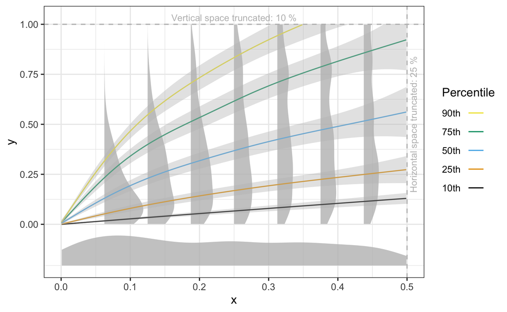

```r
quantileplot(y ~ s(x),
             data = sim_data,
             x_data_range = c(0,.5),
             y_data_range = c(0,1),
             show_ci = T)
```

Note that the vertical densities are redistributed across the user-specified `x_data_range`.

## Customization 2: Make modifications as in `ggplot2`

Because the basic `quantileplot` contains a `ggplot2` object in the `plot` element, you can modify the output by providing plotting layers. For instance, you can add a custom title, change colors, modify axes, etc.

[output not shown]

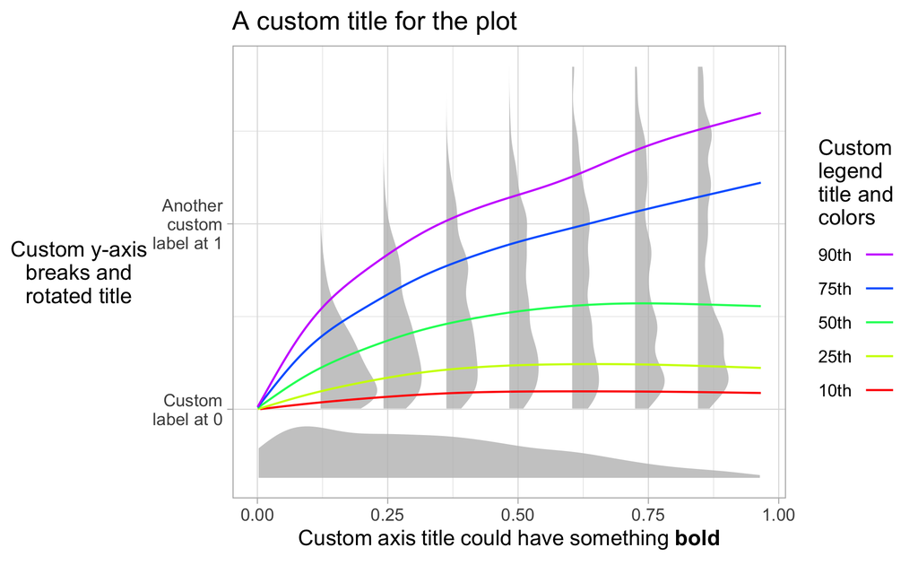

```r
library(ggplot2)
my_plot <- quantileplot(y ~ s(x), data = sim_data)
my_plot$plot +
  ggtitle("A custom title for the plot") +
  theme_light() +
  scale_color_manual(values = rainbow(5),
                     guide = guide_legend(reverse = TRUE, label.position = "left",
                                          title = "Custom\nlegend\ntitle and\ncolors")) +
  xlab(expression(Custom~axis~title~could~have~something~bold(bold))) +
  scale_y_continuous(breaks = c(0,1,2),
                     labels = c("Custom\nlabel at 0",
                                "Another\ncustom\nlabel at 1",
                                "Custom\nlabel at 2"),
                     name = "Custom y-axis\nbreaks and\nrotated title") +
  theme(axis.title.y = element_text(angle = 0, vjust = .5))
```

If you want to modify the axis limits after the fact, you need to use `coord_cartesian()` because this is how `quantileplot()` set the axis limits.

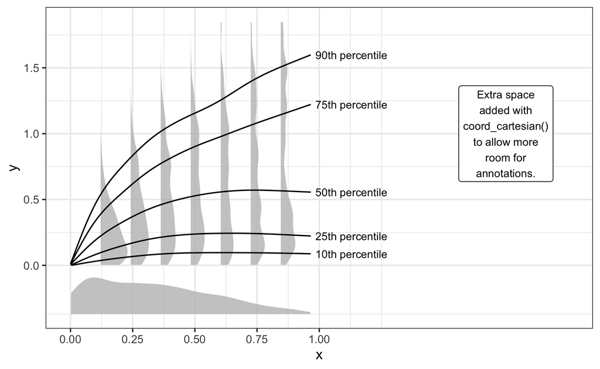

```r
my_plot <- quantileplot(y ~ s(x), data = sim_data, quantile_notation = "label")
my_plot$plot +
  coord_cartesian(xlim = c(0,2)) +
  annotate(geom = "label", x = 1.75, y = 1,
           label = "Extra space\nadded with\ncoord_cartesian()\nto allow more\nroom for\nannotations.",
           size = 3)
```

## Additional notes

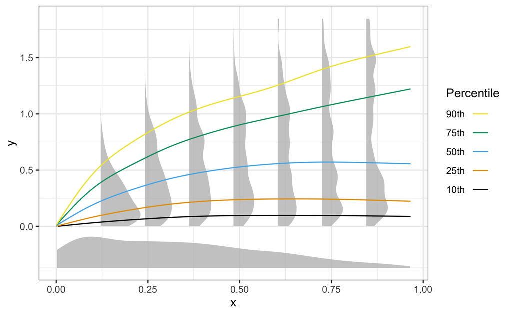

```r
quantileplot(y ~ s(x), data = sim_data, previous_fit = my_plot)
```

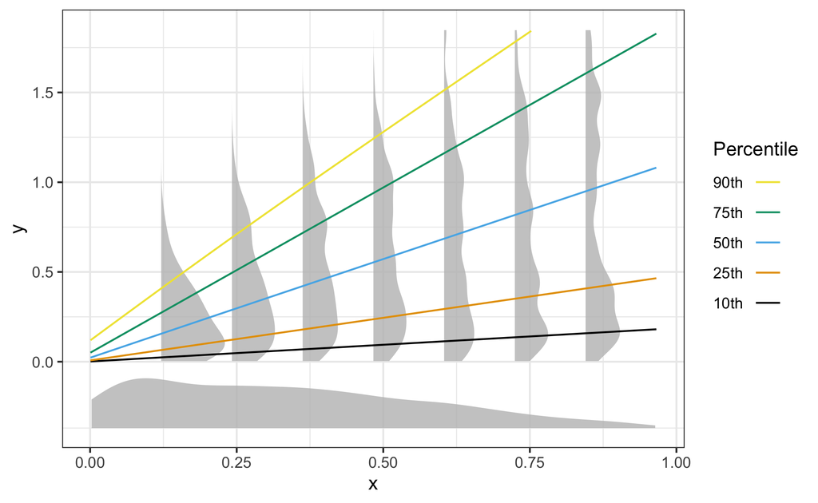

```r
quantileplot(y ~ s(x), data = sim_data, lsig = log(10))
```

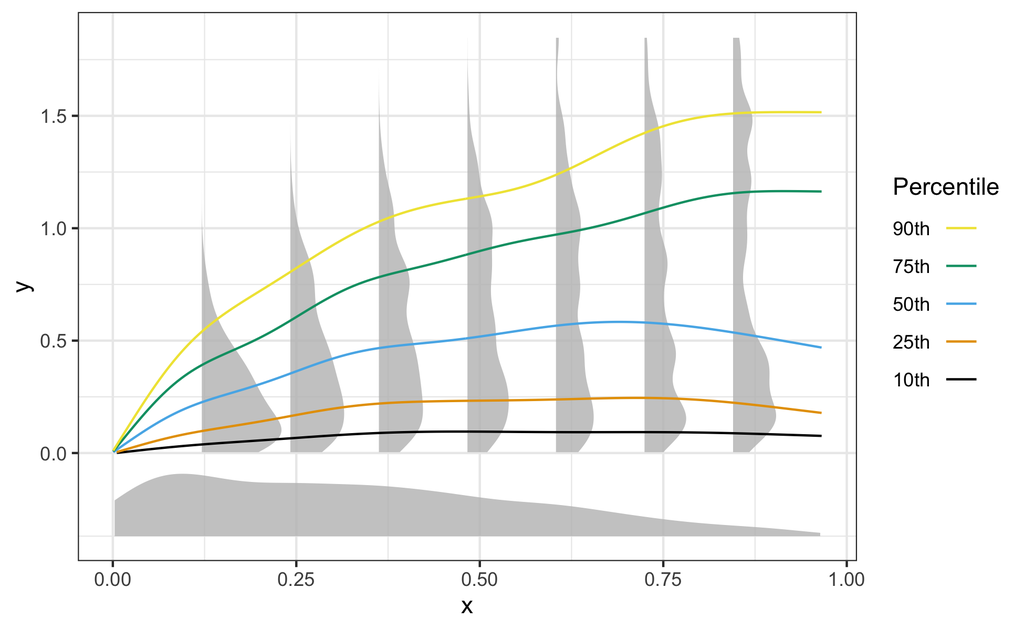

```r
quantileplot(y ~ s(x), data = sim_data, lsig = log(.01))
```